# Learning to use GGPlot

Applications on Demographic Analysis

Prepare my workspace:

```r
require(tidyverse)
```

# How to make a scatter plot

I first start experimenting with `ggplot2` using the `mpg` library:

```r
head(mpg)
```

| manufacturer | model | displ | year | cyl | trans | drv | cty | hwy | fl | class |
| --- | --- | --- | --- | --- | --- | --- | --- | --- | --- | --- |
| audi | a4 | 1.8 | 1999 | 4 | auto(l5) | f | 18 | 29 | p | compact |
| audi | a4 | 1.8 | 1999 | 4 | manual(m5) | f | 21 | 29 | p | compact |
| audi | a4 | 2.0 | 2008 | 4 | manual(m6) | f | 20 | 31 | p | compact |
| audi | a4 | 2.0 | 2008 | 4 | auto(av) | f | 21 | 30 | p | compact |
| audi | a4 | 2.8 | 1999 | 6 | auto(l5) | f | 16 | 26 | p | compact |
| audi | a4 | 2.8 | 1999 | 6 | manual(m5) | f | 18 | 26 | p | compact |

I start producing the simplest plot without any other layer:

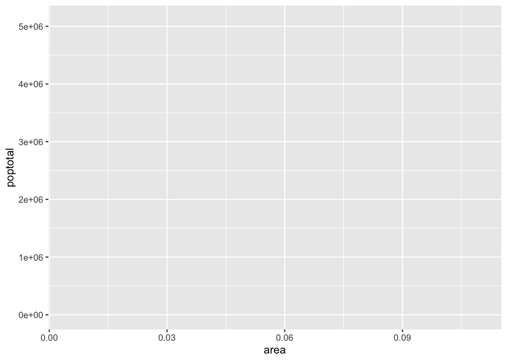

```r
ggplot(midwest, aes( x= area, y=poptotal))
```

Then I can start adding layers on top of this one, like using the command `geom_point()` and adding it (`+`) to the object:

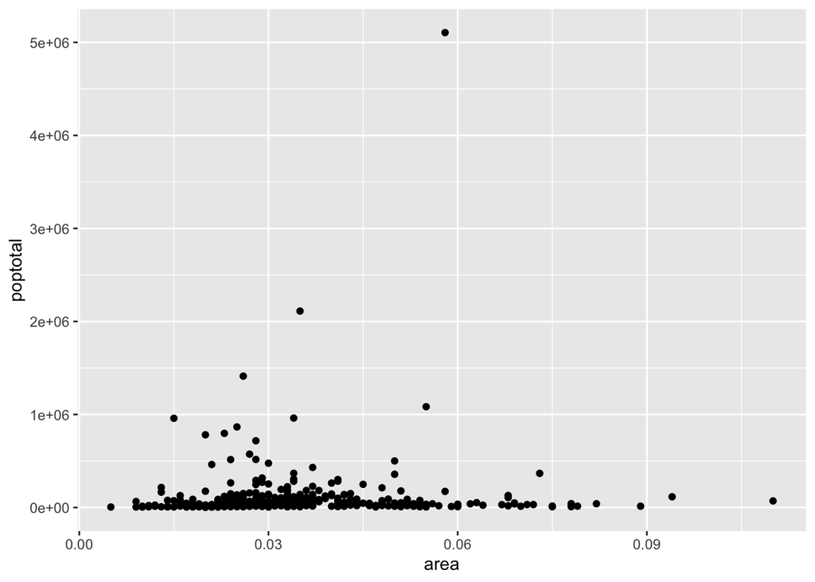

```r
ggplot(midwest, aes( x= area, y=poptotal)) + geom_point()
```

I can start making it more beautiful adding a fit line as well as a confidence interval area:

```r
g <- ggplot(midwest, aes( x= area, y=poptotal)) + geom_point(col = "red", size = 0.9) + geom_smooth(method = "lm")
```

## Adjusting the X and Y axis limits

I can make it look better in two ways:

1. Zooming in (without removing outliers or *influential observations*)
2. Deleting points outside the range

### Zooming in

I make use of the command `coord_cartesian()` and specifying the `xlim` and `ylim` that I wish to zoom in into:

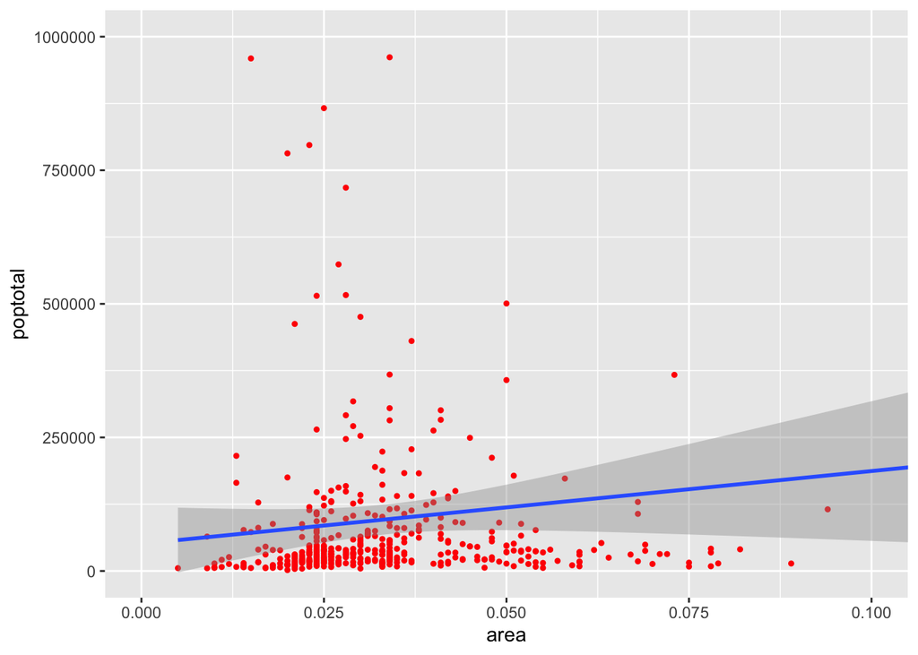

```r
g1 <- g + coord_cartesian(xlim = c(0,0.1), ylim = c(0,1000000))
plot(g1)
```

### Deleting outliers

I can delete the points outside the limits by using the same `xlim` and `ylim` and specifying limits (in this case from `0,0.1` in the x-axis and `0,1e+6` in y-axis). Because these are influential observations, I can also plot *over* this “truncated” linear fit line with the zoomed version to see how the slope changes:

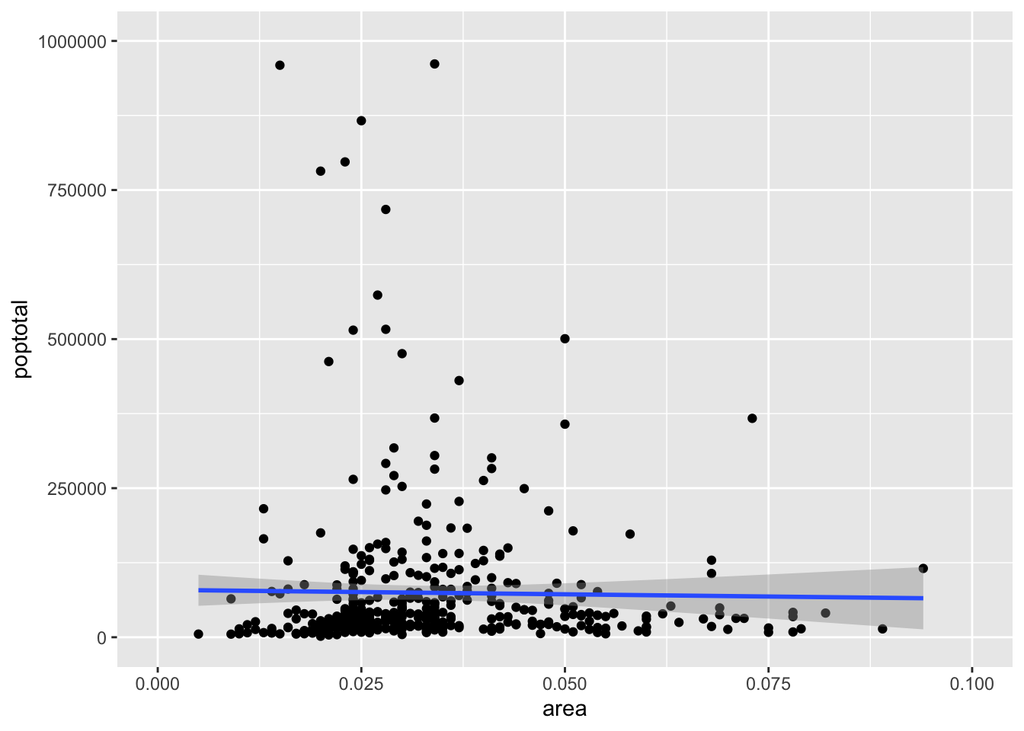

```r
g <- ggplot(midwest, aes(x= area, y=poptotal)) + geom_point() + geom_smooth(method = "lm") # Generate plot
g + xlim(c(0, 0.1)) + ylim(c(0, 1000000))  # Delete points
```

#### Stuck!

I cannot find a way to overlap the linear fit from the *zoomed in* graph from the *“truncated”* graph, so as to compare the slopes, like the graph we saw in class:

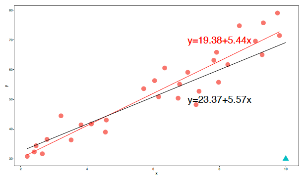

Class graph